# IODS course project

Evgeni Grazhdankin

# Introduction to Open Data Science - Course Project

# About the project

*Ruminations about the Introduction to Open Data Science (IODS) 2021*

## Feelings

The course `Introduction to Open Data Science (IODS)` feels like a good introduction to the **R-Rstudio-git** pipeline advocating for reproducible well-documented research.

Challenges may arise due to

- various backgrounds of the students
- technological hurdles

## Outcomes

I hope the course will generate mindsets favoring *open research* equipped with *technical skills* to produce good research output.

I hope to learn not only technical skills but also ways to endorse open data science.

## Where to find the course

I found the course in Sisu. Apparently it is also found in the [MOOC](https://mooc.helsinki.fi) platform.

## Repo

A fork of the course can be found at my [repo](https://github.com/evgrazhda/IODS-project).

# Week 2 - Simple linear regression

```r
date()
```

```
## [1] "Fri Nov 12 21:29:04 2021"
```

## Introduction

This week, we are analyzing and modeling a survey data concerning the approaches to learning. Description of the data can be found [here](https://www.mv.helsinki.fi/home/kvehkala/JYTmooc/JYTOPKYS3-meta.txt) and [here](https://www.mv.helsinki.fi/home/kvehkala/JYTmooc/JYTOPKYS2-meta.txt).

The data has been preprocessed to include variables on gender, age, attitude, exam points, and scores on deep, surface and strategic questions.

## Dataset

Begin by loading the analysis data. Let’s use the “official” csv-file; an R script to produce the wrangled data is in the [repo](https://github.com/evgrazhda/IODS-project).

```r
# read in the data
learning2014 <- read.csv("http://s3.amazonaws.com/assets.datacamp.com/production/course_2218/datasets/learning2014.txt", header = TRUE, sep = ",")

dim(learning2014)
```

```
## [1] 166   7
```

There are 166 rows and 7 columns.

```r
str(learning2014)
```

```
## 'data.frame':    166 obs. of  7 variables:
##  $ gender  : chr  "F" "M" "F" "M" ...
##  $ age     : int  53 55 49 53 49 38 50 37 37 42 ...
##  $ attitude: num  3.7 3.1 2.5 3.5 3.7 3.8 3.5 2.9 3.8 2.1 ...
##  $ deep    : num  3.58 2.92 3.5 3.5 3.67 ...
##  $ stra    : num  3.38 2.75 3.62 3.12 3.62 ...
##  $ surf    : num  2.58 3.17 2.25 2.25 2.83 ...
##  $ points  : int  25 12 24 10 22 21 21 31 24 26 ...
```

The variables are mostly numeric. Gender is of character value, change it to factor.

```r
# change to factor
learning2014$gender <- as.factor(learning2014$gender)

summary(learning2014)
```

```
##  gender       age           attitude          deep            stra
##  F:110   Min.   :17.00   Min.   :1.400   Min.   :1.583   Min.   :1.250
##  M: 56   1st Qu.:21.00   1st Qu.:2.600   1st Qu.:3.333   1st Qu.:2.625
##          Median :22.00   Median :3.200   Median :3.667   Median :3.188
##          Mean   :25.51   Mean   :3.143   Mean   :3.680   Mean   :3.121
##          3rd Qu.:27.00   3rd Qu.:3.700   3rd Qu.:4.083   3rd Qu.:3.625
##          Max.   :55.00   Max.   :5.000   Max.   :4.917   Max.   :5.000
##       surf           points
##  Min.   :1.583   Min.   : 7.00
##  1st Qu.:2.417   1st Qu.:19.00
##  Median :2.833   Median :23.00
##  Mean   :2.787   Mean   :22.72
##  3rd Qu.:3.167   3rd Qu.:27.75
##  Max.   :4.333   Max.   :33.00
```

Seems like most of the students are female, age spans 17-55, exam points are between 7-33 and the question variables are capped at 5 (from documentation, on a scale 1-5).

## Graphical overview

Using GGlally::ggpairs, we can plot the distribution of the variables, correlation (with significance), boxplots and scatterplots stratified by the gender.

```r
library(GGally)
```

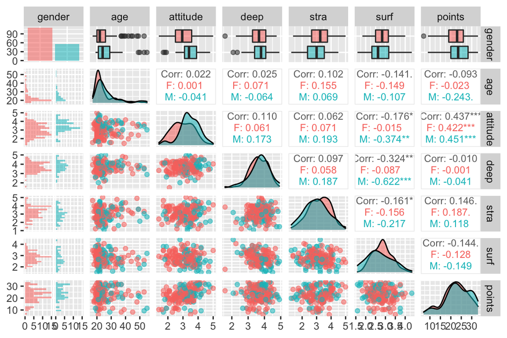

```r
library(ggplot2)

p <- ggpairs(learning2014, mapping = aes(col = gender, alpha = 0.3),
             lower = list(combo = wrap("facethist", bins = 20)),
             upper = list(continuous = wrap("cor", size = 3)))

p
```

We see that

- Most students are female
- Age is right skewed (more of smaller age)
- There is a positive correlation between `points` and `attitude`
- There is, as expected, a negative correlation between `surf` and `deep` questions
- There is a negative correlation between `surf` and `attitude`
- There is a negative correlation between `surf` and `stra` questions
- Distribution of the exam points is not perfectly normal (can be tested with e.g. stats::shapiro.test)

## Linear regression

For pedagogical reasons, let’s fit a simple multivariable linear regression first with four (instead of three; choosing three would not change the results) explanatory variables, ie. regress exam points on other variables. Choose variables based on their absolute correlation with the exam points.

```r
sort(abs(cor(learning2014[, -1])[, c("points")]))
```

```
##       deep        age       surf       stra   attitude     points
## 0.01014849 0.09319032 0.14435642 0.14612247 0.43652453 1.00000000
```

```r
model <- lm(points ~ attitude + stra + surf + age, data = learning2014)

summary(model)
```

```
##
## Call:
## lm(formula = points ~ attitude + stra + surf + age, data = learning2014)
##
## Residuals:
##      Min       1Q   Median       3Q      Max
## -17.8639  -3.2849   0.3086   3.4548  10.7028
##
## Coefficients:
##             Estimate Std. Error t value Pr(>|t|)
## (Intercept) 13.70644    3.96234   3.459 0.000694 ***
## attitude     3.38964    0.57041   5.942 1.68e-08 ***
## stra         0.93123    0.53986   1.725 0.086459 .
## surf        -0.76565    0.80258  -0.954 0.341524
## age         -0.09466    0.05346  -1.771 0.078502 .
## ---
## Signif. codes:  0 '***' 0.001 '**' 0.01 '*' 0.05 '.' 0.1 ' ' 1
##
## Residual standard error: 5.262 on 161 degrees of freedom
## Multiple R-squared:  0.2226, Adjusted R-squared:  0.2033
## F-statistic: 11.52 on 4 and 161 DF,  p-value: 2.987e-08
```

From the summary, the intercept is very significantly non-zero based on a t-test (H_0: intercept is zero, H_1: intercept is not zero) although the result is not very meaningful as e.g. age cannot be zero in this context.

The `attitude` variable has a very significant effect on the exam points (p-value about zero for a t-test for H_0: attitude has no effect on the slope when the other variables are kept constant, H_1: attitude has an effect). Variables `stra` and `age` are weakly significant or non-significant depending on the nomenclature (same test). Variable `surf` is not significant, let’s remove it and refit.

```r
model <- lm(points ~ attitude + stra + age, data = learning2014)

summary(model)
```

```
##
## Call:
## lm(formula = points ~ attitude + stra + age, data = learning2014)
##
## Residuals:
##      Min       1Q   Median       3Q      Max
## -18.1149  -3.2003   0.3303   3.4129  10.7599
##
## Coefficients:
##             Estimate Std. Error t value Pr(>|t|)
## (Intercept) 10.89543    2.64834   4.114 6.17e-05 ***
## attitude     3.48077    0.56220   6.191 4.72e-09 ***
## stra         1.00371    0.53434   1.878   0.0621 .
## age         -0.08822    0.05302  -1.664   0.0981 .
## ---
## Signif. codes:  0 '***' 0.001 '**' 0.01 '*' 0.05 '.' 0.1 ' ' 1
##
## Residual standard error: 5.26 on 162 degrees of freedom
## Multiple R-squared:  0.2182, Adjusted R-squared:  0.2037
## F-statistic: 15.07 on 3 and 162 DF,  p-value: 1.07e-08
```

Now all explanatory variables are significant with a 0.10 significance cutoff.

The F-test is significant, some of the variables are therefore associated with the response variable (have non-zero coefficient).

## Interpretation of the linear model

From the summary above, we see that as `attitude` increases by one, exam points increase by about 3.48 when other variables are kept constant. For `stra`, the value is about 1.00. Age seems to have a smaller effect, with an additional year decreasing exam points by around 0.08 if other variable do not change.

Multiple R-squared is 0.2182, meaning that the three explanatory variables account for approximately 22% variation in the exam points. This seems quite low and we should be careful when e.g. predicting exam points for new students with this model. The adjusted R-squared considers the number of explanatory variables and has here a similar, a bit smaller, value to the unadjusted R-squared.

## Diagnostics

Linear models carry assumptions that need to be verified. We use diagnostic plots for visual assessment.

### Residuals versus fitted

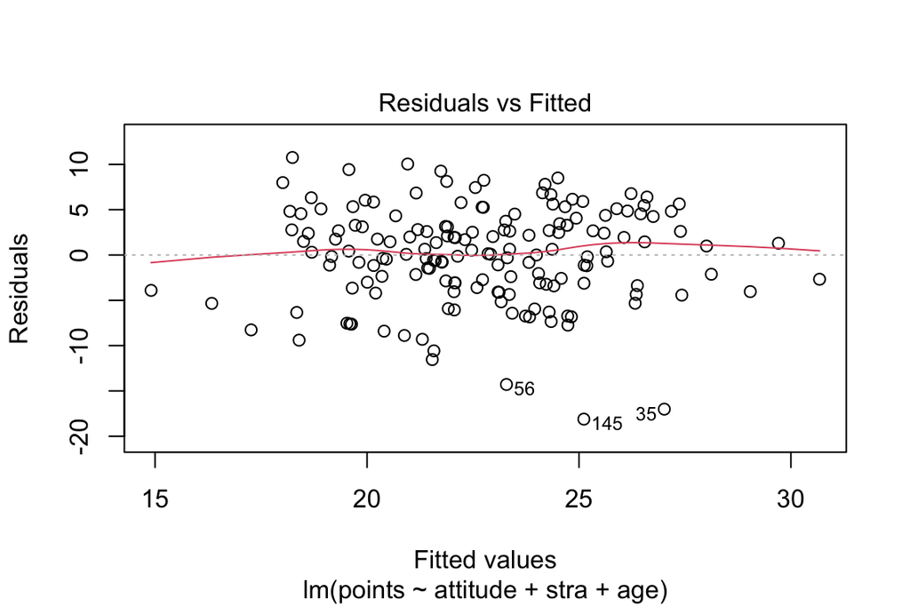

```r
# residuals vs fitted values
plot(model, which = 1)
```

There doesn’t seem to be a clear pattern (maybe visually somewhat of a funnel with decreasing variance but Breusch-Pagan test `car::ncvTest(model)` doesn’t detect heteroskedasticity) in the residuals versus fitted values in the sense that the variance in residuals is similar across the fitted values. Also, the variation is approximately symmetrical around zero. *Constant variance assumption* appears to be met. Linear model appears to be OK for the data.

Three outliers (set by `id.n` in plot.lm) are detected (rows 35, 56 and 145), let’s check them.

```r
print(learning2014[c(35, 56, 145), ])
```

```
##     gender age attitude     deep  stra     surf points
## 35       M  20      4.2 4.500000 3.250 1.583333     10
## 56       F  45      3.8 3.000000 3.125 3.250000      9
## 145      F  21      3.5 3.916667 3.875 3.500000      7
```

```
## [1] "attitude"
```

```
## [1] "stra"
```

```
## [1] "age"
```

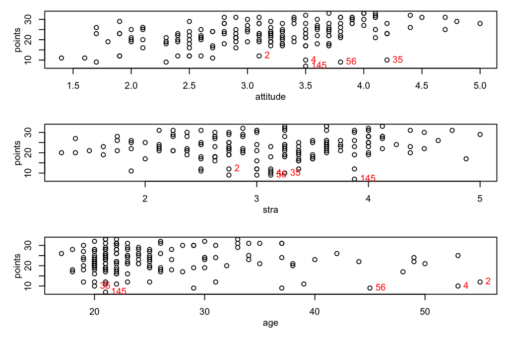

```r
annotate <- c(35, 56, 145, 4, 2)  # 4 and 2 for leverage below

# make the plot tighter
op <- par(mfrow=c(3, 1),
          mar = c(4, 4, 1, 1),
          mgp = c(2, 1, 0))

parameters <- c("attitude", "stra", "age")

for (param in parameters) {
  print(param)
  plot(learning2014[, param], learning2014$points,
       xlab = param, ylab = "points")

  text(learning2014[annotate, param],
       learning2014[annotate, "points"],
       annotate, pos = 4, col = "red")
}
```

```r
par(op) # return original par
```

It appears that here are the students that got low exam points despite having a high attitude value.

Plot boxplot for assessment of symmetry of the residual distribution.

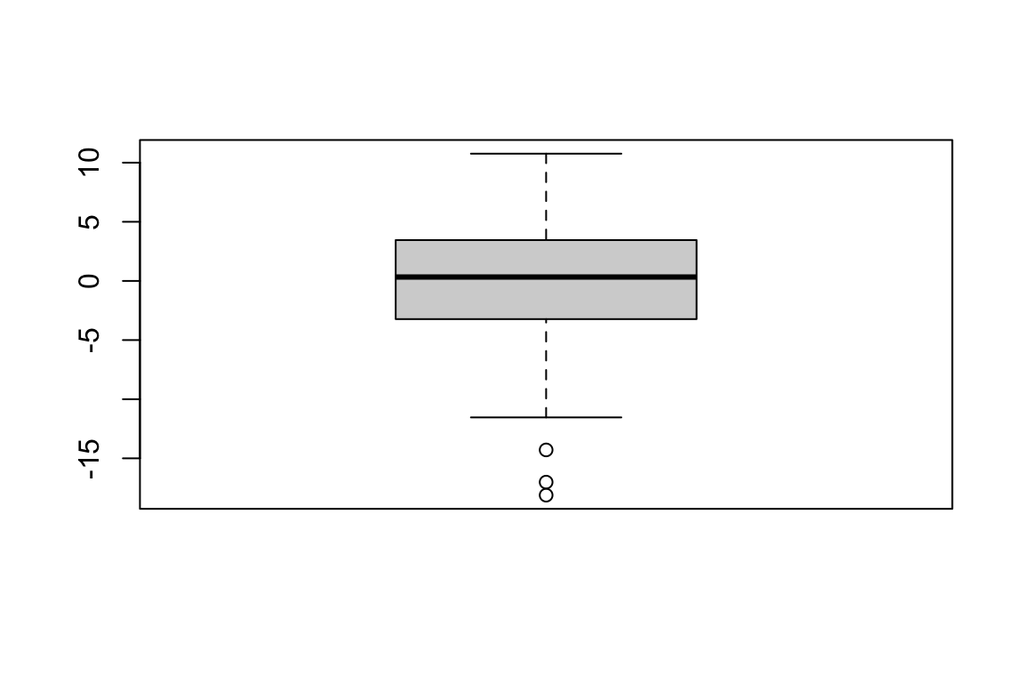

```r
boxplot(resid(model))
```

Does not seem too bad, but is not perfectly symmetric. QQ-plot will aid in deciding normality.

### QQ-plot

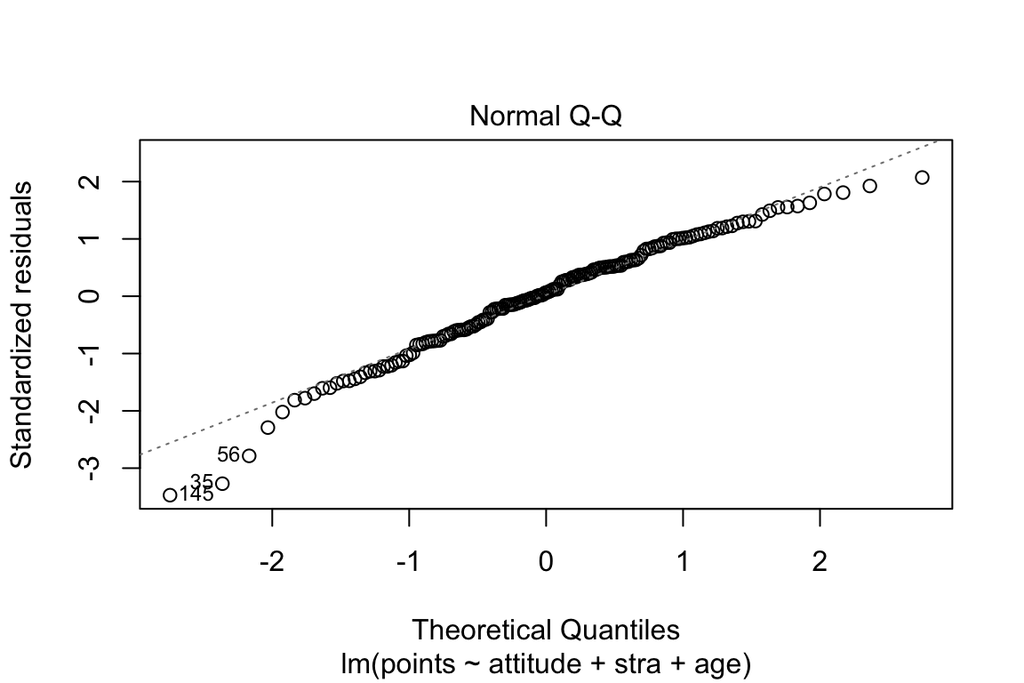

```r
# qq-plot
plot(model, which = 2)
```

Standardized residuals follow the linear pattern quite reasonably with the same outlier exceptions as above. Hence, there is no strong reason to suspect deviation from normality in the distribution of the residuals.

### Residuals versus leverage

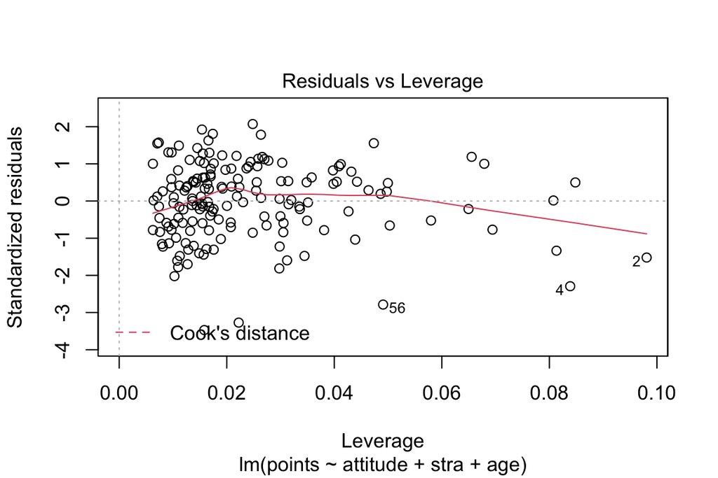

```r
# residuals vs. leverage
plot(model, which = 5)
```

Observations 2, 4 and 56 have been marked as outliers, they have relatively high influence of the regression line compared to other observations. We can rerun the model without these to see if the multiple R-squared is increased.

Cook’s distance is also low, supporting the notion that there are no outliers having a great effect on the linear fit.

```r
max(cooks.distance(model))
```

```
## [1] 0.1202162
```

```r
summary(lm(points ~ attitude + stra + age, data = learning2014[-c(2, 4, 56), ]))
```

```
##
## Call:
## lm(formula = points ~ attitude + stra + age, data = learning2014[-c(2,
##     4, 56), ])
##
## Residuals:
##     Min      1Q  Median      3Q     Max
## -17.822  -3.520   0.348   3.617  10.919
##
## Coefficients:
##             Estimate Std. Error t value Pr(>|t|)
## (Intercept)  8.38472    2.58566   3.243  0.00144 **
## attitude     3.64594    0.53695   6.790 2.11e-10 ***
## stra         0.84219    0.51066   1.649  0.10108
## age          0.01968    0.05677   0.347  0.72930
## ---
## Signif. codes:  0 '***' 0.001 '**' 0.01 '*' 0.05 '.' 0.1 ' ' 1
##
## Residual standard error: 5.008 on 159 degrees of freedom
## Multiple R-squared:  0.2419, Adjusted R-squared:  0.2276
## F-statistic: 16.91 on 3 and 159 DF,  p-value: 1.394e-09
```

Multiple R-square is indeed a bit better. However, removal of the outliers would have to be justified from the data (e.g. are these students somehow different).

### VIF

```r
library(car)
vif(model)
```

```
## attitude     stra      age
## 1.004083 1.014233 1.010865
```

Variance inflation factors are less than 10 (textbook), so there is no concern for collinearity.

### AIC

We can try automatic stepwise model selection by AIC criterion.

```r
library(MASS)
model.full <- lm(points ~ gender + age + attitude + deep + stra + surf,
                 data = learning2014)
stepAIC(model.full, direction = "both")
```

```
## Start:  AIC=558.36
## points ~ gender + age + attitude + deep + stra + surf
##
##            Df Sum of Sq    RSS    AIC
## - gender    1      0.11 4408.5 556.36
## - surf      1     47.79 4456.1 558.15
## - deep      1     49.00 4457.3 558.19
## <none>                  4408.3 558.36
## - stra      1     83.78 4492.1 559.48
## - age       1     87.88 4496.2 559.63
## - attitude  1    919.82 5328.2 587.82
##
## Step:  AIC=556.36
## points ~ age + attitude + deep + stra + surf
##
##            Df Sum of Sq    RSS    AIC
## - surf      1     47.69 4456.1 556.15
## - deep      1     49.11 4457.6 556.20
## <none>                  4408.5 556.36
## - stra      1     88.35 4496.8 557.66
## - age       1     90.16 4498.6 557.72
## + gender    1      0.11 4408.3 558.36
## - attitude  1    999.18 5407.6 588.27
##
## Step:  AIC=556.15
## points ~ age + attitude + deep + stra
##
##            Df Sum of Sq    RSS    AIC
## - deep      1     26.61 4482.8 555.14
## <none>                  4456.1 556.15
## + surf      1     47.69 4408.5 556.36
## - age       1     75.36 4531.5 556.93
## - stra      1    106.07 4562.2 558.05
## + gender    1      0.02 4456.1 558.15
## - attitude  1   1084.38 5540.5 590.30
##
## Step:  AIC=555.14
## points ~ age + attitude + stra
##
##            Df Sum of Sq    RSS    AIC
## <none>                  4482.8 555.14
## - age       1     76.62 4559.4 555.95
## + deep      1     26.61 4456.1 556.15
## + surf      1     25.20 4457.6 556.20
## - stra      1     97.64 4580.4 556.71
## + gender    1      0.01 4482.8 557.14
## - attitude  1   1060.72 5543.5 588.39
```

```
##
## Call:
## lm(formula = points ~ age + attitude + stra, data = learning2014)
##
## Coefficients:
## (Intercept)          age     attitude         stra
##    10.89543     -0.08822      3.48077      1.00371
```

The produced model is the same we derived earlier.

### Brute force

Finally, we can try to brute force all linear models of simple combination of explanatory variables.

```r
library(olsrr)
res <- olsrr::ols_step_all_possible(model.full)

res[order(res$adjr, decreasing = TRUE), ]
```

```
##    Index N                         Predictors     R-Square Adj. R-Square
## 62    57 5        age attitude deep stra surf 0.2311318189   0.207104688
## 33    22 3                  age attitude stra 0.2181719645   0.203693668
## 52    42 4             age attitude deep stra 0.2228135019   0.203504521
## 54    43 4             age attitude stra surf 0.2225665343   0.203251417
## 63    63 6 gender age attitude deep stra surf 0.2311510113   0.202137842
## 43    44 4           gender age attitude stra 0.2181729919   0.198748718
## 57    58 5      gender age attitude deep stra 0.2228168858   0.198529914
## 59    59 5      gender age attitude stra surf 0.2226046106   0.198311005
## 53    45 4             age attitude deep surf 0.2157221484   0.196236984
## 56    46 4            attitude deep stra surf 0.2154077956   0.195914822
## 17     7 2                      attitude stra 0.2048096617   0.195052725
## 38    23 3                 attitude deep stra 0.2096692889   0.195033535
## 34    24 3                  age attitude surf 0.2081990315   0.193536051
## 40    25 3                 attitude stra surf 0.2074263400   0.192749050
```

[output cut: 113 more lines]

By adjusted R-Square, it appears that the three variable model we used before fares very well compared to the full model. Attitude alone is also quite good in comparison and could be chosen by parsimony.

(more chapters to be added similarly as we proceed with the course!)